# p8105_hw3_fc2691

FC

10/16/2021

```r
library(tidyverse)
```

```r
library(p8105.datasets)
library(knitr)

knitr::opts_chunk$set(
  fig.width = 10,
  fig.asp = .6,
  out.width = "90%"
)

theme_set(theme_minimal() + theme(legend.position = "bottom"))

options(
  ggplot2.continuous.colour = "viridis",
  ggplot2.continuous.fill = "viridis"
)

scale_colour_discrete = scale_colour_viridis_d
scale_fill_discrete = scale_fill_viridis_d
```

### Problem 1

The goal is to do some exploration of this dataset. To that end, write a short description of the dataset, noting the size and structure of the data, describing some key variables, and giving illstrative examples of observations. Then, do or answer the following (commenting on the results of each):

```r
data("instacart") #load a dataset
library(ggplot2)
# Find out the most ordered aisle.
insta_aisle =
  instacart %>%
  janitor::clean_names() %>%
  distinct() %>%
  group_by(aisle, aisle_id, department) %>%
  summarise(aisles_obs = n()) %>%
  arrange(desc(aisles_obs))
kable(insta_aisle[1:5,], caption = "Instacart Aisles Count")
```

Instacart Aisles Count

| aisle | aisle_id | department | aisles_obs |
| --- | --- | --- | --- |
| fresh vegetables | 83 | produce | 150609 |
| fresh fruits | 24 | produce | 150473 |
| packaged vegetables fruits | 123 | produce | 78493 |
| yogurt | 120 | dairy eggs | 55240 |
| packaged cheese | 21 | dairy eggs | 41699 |

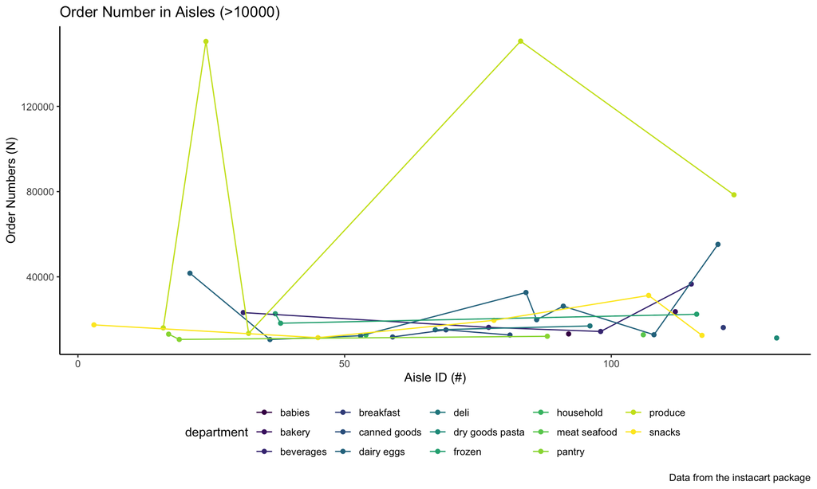

```r
# Make a plot shows the number of orders in each aisle.
plot_insta_aisle =
  insta_aisle %>%
  filter(aisles_obs > 10000) %>%
  ggplot(aes(x = aisle_id, y = aisles_obs, color = department)) +
    geom_point() + geom_line() +
    theme_classic() +
    theme(legend.position = "bottom") +
    labs(
    title = "Order Number in Aisles (>10000)",
    x = "Aisle ID (#)",
    y = "Order Numbers (N)",
    caption = "Data from the instacart package"
  )
plot_insta_aisle
```

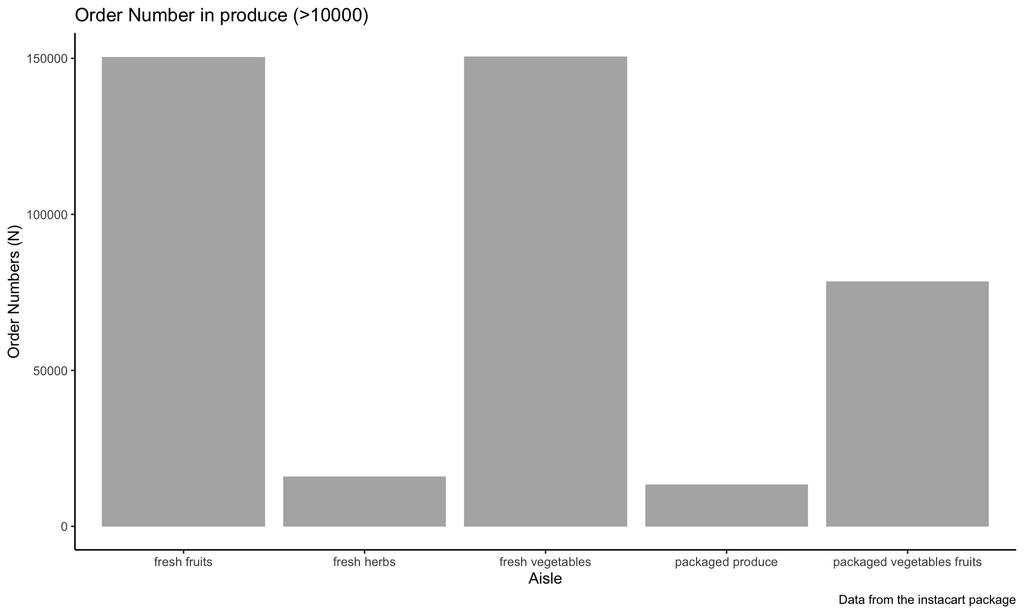

```r
####
#Make a plot shows the number of order items in produce
plot_insta_prod =
  insta_aisle %>%
  filter(department == 'produce' & aisles_obs > 10000) %>%
  ggplot(aes(x = aisle, y = aisles_obs)) +
    geom_bar(stat = "identity", alpha = 0.5) +
    theme_classic() +
    theme(legend.position = "bottom") +
    labs(
    title = "Order Number in produce (>10000)",
    x = "Aisle",
    y = "Order Numbers (N)",
    caption = "Data from the instacart package"
  )
plot_insta_prod
```

- How many aisles are there, and which aisles are the most items ordered from?  
  **ANSWER**: There are 134 aisles in this instacart data. Fresh vegetables are the most ordered items from which reached about 150609 orders.
- Make a plot that shows the number of items ordered in each aisle, limiting this to aisles with more than 10000 items ordered. Arrange aisles sensibly, and organize your plot so others can read it.
- Make a table showing the three most popular items in each of the aisles “baking ingredients”, “dog food care”, and “packaged vegetables fruits”. Include the number of times each item is ordered in your table.

```r
# Show the three most popular items in three aisles.
pop_items =
  instacart %>%
  janitor::clean_names() %>%
  filter(aisle == 'baking ingredients' | aisle == 'dog food care' | aisle == 'packaged vegetables fruits') %>%
  distinct() %>%
  group_by(aisle, product_name) %>%
  summarise(pop_items_obs = n()) %>%
  arrange(aisle, desc(pop_items_obs)) %>%
  slice(1:3)
kable(pop_items, caption = "Three Most Popular Items in Aisles" )
```

Three Most Popular Items in Aisles

| aisle | product_name | pop_items_obs |
| --- | --- | --- |
| baking ingredients | Light Brown Sugar | 499 |
| baking ingredients | Pure Baking Soda | 387 |
| baking ingredients | Cane Sugar | 336 |
| dog food care | Snack Sticks Chicken & Rice Recipe Dog Treats | 30 |
| dog food care | Organix Chicken & Brown Rice Recipe | 28 |
| dog food care | Small Dog Biscuits | 26 |
| packaged vegetables fruits | Organic Baby Spinach | 9784 |
| packaged vegetables fruits | Organic Raspberries | 5546 |
| packaged vegetables fruits | Organic Blueberries | 4966 |

- Make a table showing the mean hour of the day at which Pink Lady Apples and Coffee Ice Cream are ordered on each day of the week; format this table for human readers (i.e. produce a 2 x 7 table).

```r
# The mean hour of the day for lady apples and coffee ice cream
mean_hrs_sum =
  instacart %>%
  janitor::clean_names() %>%
  filter(product_name == 'Pink Lady Apples' | product_name == 'Coffee Ice Cream') %>%
  distinct() %>%
  group_by(product_name, order_dow) %>%
  summarize(mean_hrs = mean(order_hour_of_day)) %>%
  mutate(mean_hrs =
           round(as.numeric(mean_hrs), 1)) %>%
  mutate(order_dow = recode(
    order_dow,
    "0" = "Sun",
    "1" = "Mon",
    "2" = "Tue",
    "3" = "Wed",
    "4" = "Thu",
    "5" = "Fri",
    "6" = "Sat")) %>%
  pivot_wider(
    names_from = "order_dow",
    values_from = "mean_hrs"
  )
kable(mean_hrs_sum, caption = "The Mean Hour of the Day for P&C")
```

The Mean Hour of the Day for P&C

| product_name | Sun | Mon | Tue | Wed | Thu | Fri | Sat |
| --- | --- | --- | --- | --- | --- | --- | --- |
| Coffee Ice Cream | 13.8 | 14.3 | 15.4 | 15.3 | 15.2 | 12.3 | 13.8 |
| Pink Lady Apples | 13.4 | 11.4 | 11.7 | 14.2 | 11.6 | 12.8 | 11.9 |

*To that end, write a short description of the dataset, noting the size and structure of the data, describing some key variables, and giving illstrative examples of observations. Then, do or answer the following (commenting on the results of each):*  
**ANSWER**: From the dataset gained from Instacart, it’s dimension is (1384617, 15) which describes the order details from customers including information about products, order time, frequency, department and so on. It shows the most popular aisle type is fresh vegetables from the produce department (fresh fruits, fresh vegetables, packaged vegetables fruit…) which we eat often everyday. The three most popular items in “baking ingredients” aisle are light brown sugar, pure baking soda and cane sugar. The three most popular items in “dog food care” aisle are snack sticks chicken & rice recipe dog treat, organix chicken & brown rice recipe and small dog biscuits. The most three popular items in “packaged vegetable fruits” aisle are organic baby spinach, organic raspberries and organic blueberries. The mean hour of ice cream is relatively late compared to people who buy pink lady apples. And mean hour of Wed is relatively later than other days of the week for pink lady, and the mean hour for customers who buy ice cream is later on Tue to Thu.

### Problem 2

This problem uses the BRFSS (dataset_brfss.html) data. DO NOT include this dataset in your local data directory; instead, load the data from the p8105.datasets (https://github.com/P8105/p8105.datasets) package.  
First, do some data cleaning:  
- format the data to use appropriate variable names;  
- focus on the “Overall Health” topic  
- include only responses from “Excellent” to “Poor”  
- organize responses as a factor taking levels ordered from “Poor” to “Excellent”

```r
data("brfss_smart2010")

#Clean brfss data and focus on the response from "Overall Health" topic.
brfss_clean =
  brfss_smart2010 %>%
  janitor::clean_names() %>%
  distinct() %>%
  filter(topic == "Overall Health") %>%
  separate(locationdesc, into = c("state", "county"), sep = " - ") %>%
  select(year, state, county, response, data_value) %>%
  mutate(
    response = factor(response, levels = c("Poor", "Fair", "Good", "Very good", "Excellent"), order = T))
kable(brfss_clean[1:10,], caption = "BRFSS Data on 'Overall Health' Topic")
```

BRFSS Data on ‘Overall Health’ Topic

| year | state | county | response | data_value |
| --- | --- | --- | --- | --- |
| 2010 | AL | Jefferson County | Excellent | 18.9 |
| 2010 | AL | Jefferson County | Very good | 30.0 |
| 2010 | AL | Jefferson County | Good | 33.1 |
| 2010 | AL | Jefferson County | Fair | 12.5 |
| 2010 | AL | Jefferson County | Poor | 5.5 |
| 2010 | AL | Mobile County | Excellent | 15.6 |
| 2010 | AL | Mobile County | Very good | 31.3 |
| 2010 | AL | Mobile County | Good | 31.2 |
| 2010 | AL | Mobile County | Fair | 15.5 |
| 2010 | AL | Mobile County | Poor | 6.4 |

Using this dataset, do or answer the following (commenting on the results of each):  
- In 2002, which states were observed at 7 or more locations? What about in 2010?

```r
# Summarize location according to states in 2002 and 2010.
brfss_obs_02_10 =
  brfss_clean %>%
  filter(year == 2002 | year == 2010) %>%
  group_by(year, state) %>%
  summarize(location_count = n()) %>%
  filter(location_count >= 7) %>%
  pivot_wider(
    names_from = state,
    values_from = location_count
  )
kable(brfss_obs_02_10, caption = "States observed >=7 locations in 2002 and 2010")
```

States observed >=7 locations in 2002 and 2010

| year | AZ | CO | CT | DE | FL | GA | HI | ID | IL | IN | KS | LA | MA | MD | ME | MI | MN | MO | NC | NE | NH | NJ | NV | NY | OH | OK | OR | PA | RI | … |
| --- | --- | --- | --- | --- | --- | --- | --- | --- | --- | --- | --- | --- | --- | --- | --- | --- | --- | --- | --- | --- | --- | --- | --- | --- | --- | --- | --- | --- | --- | --- |
| 2002 | 10 | 20 | 35 | 15 | 35 | 15 | 20 | 10 | 15 | 10 | 15 | 15 | 40 | 30 | 10 | 20 | 20 | 10 | 35 | 15 | 25 | 40 | 10 | 25 | 20 | 15 | 15 | 50 | 20 | … |
| 2010 | 15 | 35 | 25 | 15 | 205 | 20 | 20 | 30 | 10 | 15 | 20 | 25 | 45 | 60 | 30 | 20 | 25 | 15 | 60 | 50 | 25 | 95 | 10 | 45 | 40 | 15 | 20 | 35 | 25 | … |

*ANSWER*: In 2002, AZ, CO, CT, DE, FL, GA, HI, ID, IL, IN, KS, LA, MA, MD, ME, MI, MN, MO, NC, NE, NH, NJ, NV, NY, OH, OK, OR, PA, RI, SC, SD, TN, TX, UT, VT, WA observed 7 or more locations. In 2010, besides the states observed on 2002, AL, AR, CA, IA, MS, MT, ND, NM, WY also observed 7 or more locations.  
- Construct a dataset that is limited to Excellent responses, and contains, year, state, and a variable that averages the data_value across locations within a state. Make a “spaghetti” plot of this average value over time within a state (that is, make a plot showing a line for each state across years – the geom_line geometry and group aesthetic will help).

```r
# Clean brfss response table which is limited to excellent response with the average of data_value.
brfss_response =
  brfss_clean %>%
  filter(response == "Excellent") %>% #limit to excellent response
  group_by(year, state) %>%
  summarise(avg_data_value = mean(data_value)) %>%
  mutate(avg_data_value = round(as.numeric(avg_data_value), 1))
# Show readable table for the dataset.
brfss_response_table =
  brfss_response %>%
  pivot_wider(
    names_from = year,
    values_from = avg_data_value
  )
kable(brfss_response_table[1:10,], caption = "Average Data Value within States with Excellent Response")
```

Average Data Value within States with Excellent Response

| state | 2002 | 2003 | 2004 | 2005 | 2006 | 2007 | 2008 | 2009 | 2010 |
| --- | --- | --- | --- | --- | --- | --- | --- | --- | --- |
| AK | 27.9 | 24.9 | 23.0 | 23.9 | NA | 23.5 | 20.6 | 23.2 | NA |
| AL | 18.5 | 19.5 | 20.0 | 16.2 | 23.2 | 18.6 | 15.9 | 21.6 | 18.4 |
| AR | 24.1 | 24.3 | 21.0 | 23.1 | 19.6 | 18.8 | 19.7 | 23.3 | 25.4 |
| AZ | 24.1 | 26.3 | 22.3 | 22.8 | 20.9 | 19.1 | 18.9 | 22.0 | 21.6 |
| CA | 22.7 | 22.0 | 18.1 | 23.5 | 21.2 | 24.5 | 22.9 | 24.1 | 23.9 |
| CO | 23.1 | 23.3 | 23.4 | 25.3 | 23.1 | 25.3 | 24.5 | 24.6 | 25.4 |
| CT | 29.1 | 29.2 | 26.3 | 24.2 | 25.9 | 25.1 | 26.0 | 25.6 | 24.2 |
| DC | 29.3 | 27.3 | 28.8 | 26.4 | 27.9 | 26.6 | 26.5 | 28.0 | 26.1 |
| DE | 20.9 | 21.5 | 19.4 | 20.3 | 20.4 | 19.1 | 18.4 | 19.3 | 20.3 |
| FL | 25.7 | NA | 21.7 | 25.3 | 25.5 | 21.4 | 27.4 | 22.6 | NA |

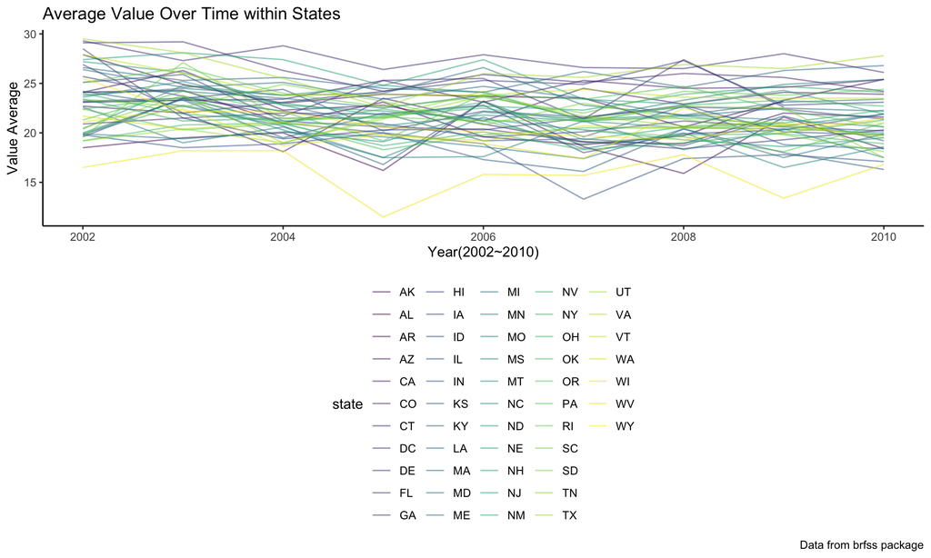

```r
# Making "spaghetti"plot
brfss_response_plot =
  brfss_response %>%
  ggplot(aes(x = year, y = avg_data_value, color = state)) +
    geom_line(alpha = 0.5) +
    theme_classic() +
    theme(legend.position = "bottom") +
    labs(
     title = "Average Value Over Time within States",
     x = "Year(2002~2010)",
     y = "Value Average",
     caption = "Data from brfss package"
  )
brfss_response_plot
```

- Make a two-panel plot showing, for the years 2006, and 2010, distribution of data_value for responses (“Poor” to “Excellent”) among locations in NY State.

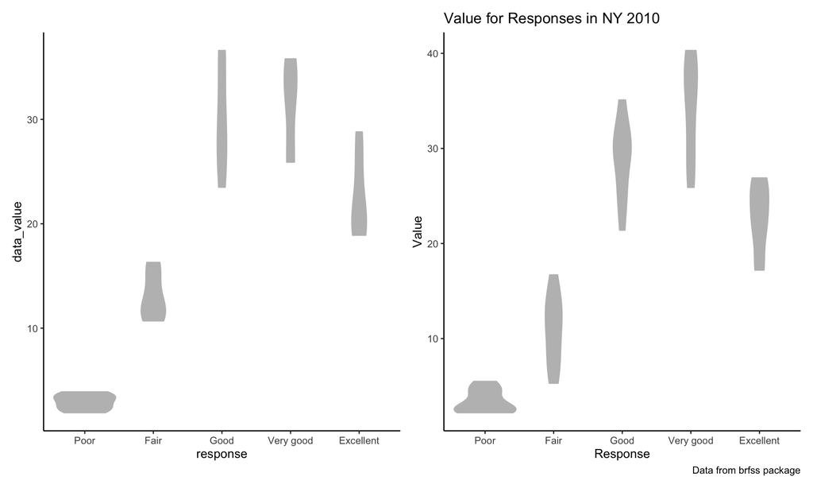

```r
library(patchwork)
#Distribution in NY in 2006
brfss_data_2006 =
  brfss_clean %>%
  filter(year == 2006 & state == "NY") %>%
  ggplot(aes(x = response, y = data_value)) +
    geom_violin(fill = "grey", color = "grey") +
    theme_classic() +
    theme(legend.position = "bottom")
  #   labs(
  #    title = "Value for Responses in NY 2006",
  #    x = "Response",
  #    y = "Value",
  #    caption = "Data from brfss package"
  # )
#Distribution in NY in 2010
brfss_data_2010 =
  brfss_clean %>%
  filter(year == 2010 & state == "NY") %>%
  ggplot(aes(x = response, y = data_value)) +
    geom_violin(fill = "grey", color = "grey") +
    theme_classic() +
    theme(legend.position = "bottom")

#Make two-panel plot
brfss_data_2006 + brfss_data_2010 +
  labs(
     title = "Value for Responses in NY 2010",
     x = "Response",
     y = "Value",
     caption = "Data from brfss package"
  )
```

### Problem 3

Accelerometers have become an appealing alternative to self-report techniques for studying physical activity in observational studies and clinical trials, largely because of their relative objectivity. During observation periods, the devices measure “activity counts” in a short period; one-minute intervals are common. Because accelerometers can be worn comfortably and unobtrusively, they produce around-the-clock observations.  
This problem uses five weeks of accelerometer data collected on a 63 year-old male with BMI 25, who was admitted to the Advanced Cardiac Care Center of Columbia University Medical Center and diagnosed with congestive heart failure (CHF). The data can be downloaded here (./data/accel_data.csv). In this spreadsheet, variables activity.* are the activity counts for each minute of a 24-hour day starting at midnight.

- Load, tidy, and otherwise wrangle the data. Your final dataset should include all originally observed variables and values; have useful variable names; include a weekday vs weekend variable; and encode data with reasonable variable classes. Describe the resulting dataset (e.g. what variables exist, how many observations, etc).

```r
#Tidy and wrangle accelerarometer data.
read_accel = read_csv("./accel_data.csv")
accel_clean =
  read_accel %>%
  janitor::clean_names() %>%
  distinct() %>%
  pivot_longer(
    activity_1:activity_1440,
    names_to = "mins",
    values_to = "act_count"
  ) %>%
  mutate(
    week =
      case_when(
        day == "Monday" ~ "weekday",
        day == "Tuesday" ~ "weekday",
        day == "Wednesday" ~ "weekday",
        day == "Thursday" ~ "weekday",
        day == "Friday" ~ "weekday",
        day == "Saturday" ~ "weekend",
        day == "Sunday" ~ "weekend")
  ) %>%
  select(day_id, day, week, mins, act_count) %>%
  mutate(
    act_level =
      ifelse(act_count < 0, "Error",
             ifelse(act_count <= 100, "Sedentary",
                    ifelse(act_count <= 800, "Low Intensity",
                           ifelse(act_count <= 2000, "Light Intensity",
                                  ifelse(act_count <= 4000, "Moderate Intensity", "Vigorous Intensity"))))))
#mutate(weekday_or_not = !(day %in% c("Saturday","Sunday"))) %>%
#weekday_or_not = ifelse(weekday_or_not == T, 'weekday','weekend')
kable(accel_clean[1:20,], caption = "Accelerometer Observation Data in 35 days")
```

Accelerometer Observation Data in 35 days

| day_id | day | week | mins | act_count | act_level |
| --- | --- | --- | --- | --- | --- |
| 1 | Friday | weekday | activity_1 | 88.37778 | Sedentary |
| 1 | Friday | weekday | activity_2 | 82.24444 | Sedentary |
| 1 | Friday | weekday | activity_3 | 64.44444 | Sedentary |
| 1 | Friday | weekday | activity_4 | 70.04444 | Sedentary |
| 1 | Friday | weekday | activity_5 | 75.04444 | Sedentary |
| 1 | Friday | weekday | activity_6 | 66.26667 | Sedentary |
| 1 | Friday | weekday | activity_7 | 53.75556 | Sedentary |
| 1 | Friday | weekday | activity_8 | 47.84444 | Sedentary |
| 1 | Friday | weekday | activity_9 | 55.46667 | Sedentary |
| 1 | Friday | weekday | activity_10 | 42.95556 | Sedentary |
| 1 | Friday | weekday | activity_11 | 46.75556 | Sedentary |
| 1 | Friday | weekday | activity_12 | 25.48889 | Sedentary |
| 1 | Friday | weekday | activity_13 | 18.97778 | Sedentary |
| 1 | Friday | weekday | activity_14 | 31.11111 | Sedentary |
| 1 | Friday | weekday | activity_15 | 22.86667 | Sedentary |
| 1 | Friday | weekday | activity_16 | 24.80000 | Sedentary |
| 1 | Friday | weekday | activity_17 | 51.02222 | Sedentary |
| 1 | Friday | weekday | activity_18 | 35.48889 | Sedentary |
| 1 | Friday | weekday | activity_19 | 40.97778 | Sedentary |
| 1 | Friday | weekday | activity_20 | 59.02222 | Sedentary |

[output not shown]

Total Activity of Accelerometer over the Day

| day_id | act_total |
| --- | --- |
| 1 | 480542.62 |
| 2 | 78828.07 |
| 3 | 376254.00 |
| 4 | 631105.00 |
| 5 | 355923.64 |
| 6 | 307094.24 |
| 7 | 340115.01 |
| 8 | 568839.00 |
| 9 | 295431.00 |
| 10 | 607175.00 |

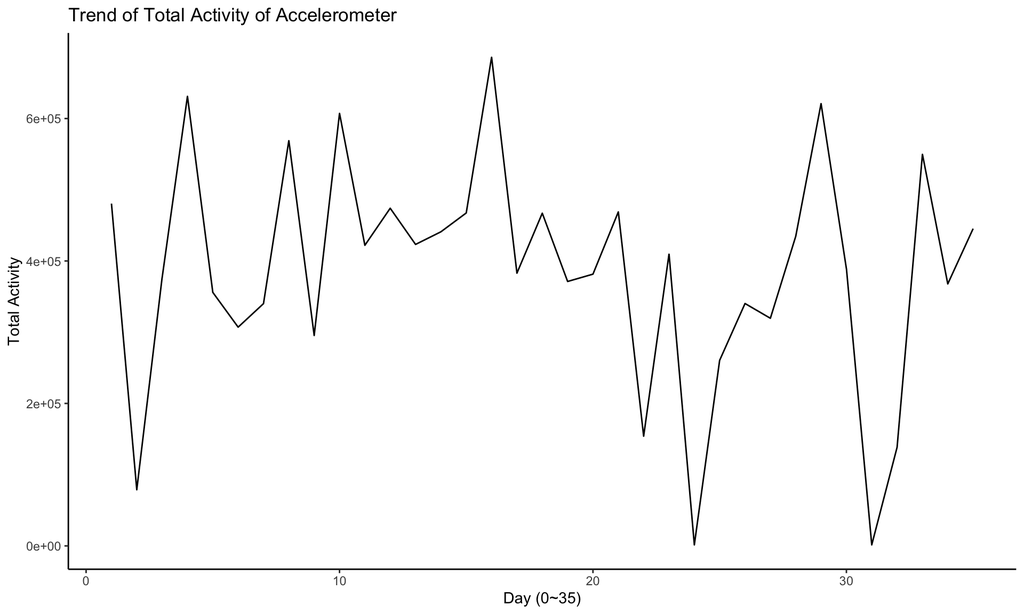

```r
#Make a plot to see trends
accel_total_plot =
  accel_act_total %>%
  ggplot(aes(x = day_id, y = act_total)) +
  geom_line() +
  theme_classic() +
  theme(legend.position = "bottom") +
  labs(
     title = "Trend of Total Activity of Accelerometer",
     x = "Day (0~35)",
     y = "Total Activity"
  )
accel_total_plot
```

**ANSWER** It seems like there is no apparent trends for the relation between total activity and day.

- Accelerometer data allows the inspection activity over the course of the day. Make a single- panel plot that shows the 24-hour activity time courses for each day and use color to indicate day of the week. Describe in words any patterns or conclusions you can make based on this graph.

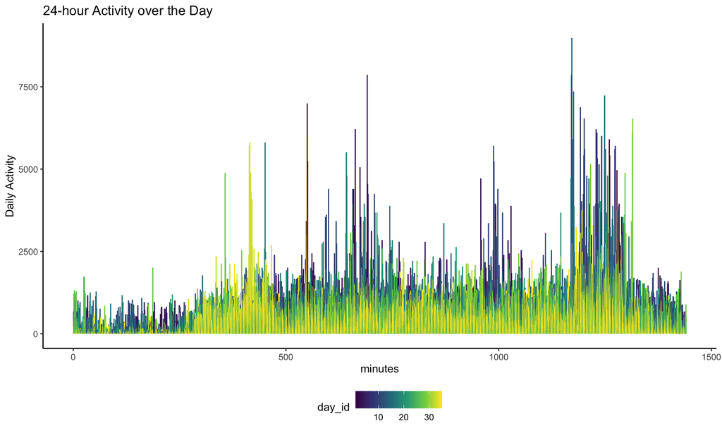

```r
# wrangle accelrometer data.
accel_act_day =
  accel_clean %>%
  mutate(act_count = round(as.numeric(act_count),2)) %>%
  separate(mins, into = c("act", "mins"), sep = "_") %>%
  mutate(mins = as.numeric(mins))
# make a plot
accel_act_day_plot =
  accel_act_day %>%
  ggplot(aes(x = mins, y = act_count, color = day_id)) +
  geom_line() +
  theme_classic() +
  theme(legend.position = "bottom") +
  labs(
     title = "24-hour Activity over the Day",
     x = "minutes",
     y = "Daily Activity"
  )
accel_act_day_plot
```